# Convolutional Neural Networks

## Algorithm for a Dog Identification App

### Why We're Here

In this notebook, we will develop an algorithm that could be used as part of a mobile or web app. At the end of this project, our code will accept any user-supplied image as input. If a dog is detected in the image, it will provide an estimate of the dog's breed. If a human is detected, it will provide an estimate of the dog breed that is most resembling.  
In this real-world setting, we will need to piece together a series of models to perform different tasks; for instance, the algorithm that detects humans in an image will be different from the CNN that infers dog breed. There are many points of possible failure, and no perfect algorithm exists. Our imperfect solution will nonetheless create a fun user experience!

We break the notebook into separate steps. Feel free to use the links below to navigate the notebook.

- Step 0: Import Datasets
- Step 1: Detect Humans
- Step 2: Detect Dogs
- Step 3: CNN to Classify Dog Breeds (from Scratch)
- Step 4: CNN to Classify Dog Breeds (using Transfer Learning)
- Step 5: Our Algorithm
- Step 6: Test Our Algorithm

## Step 0: Import Datasets

```python
import os
os.environ["KMP_DUPLICATE_LIB_OK"]="TRUE"
```

```python
import numpy as np
from glob import glob

# load filenames for human and dog images
human_files = np.array(glob("lfw/*/*"))
dog_files = np.array(glob("dogImages/*/*/*"))

# print number of images in each dataset
print('There are %d total human images.' % len(human_files))
print('There are %d total dog images.' % len(dog_files))
```

```
There are 13234 total human images.
There are 8351 total dog images.
```

## Step 1: Detect Humans

In this section, we use OpenCV's implementation of [Haar feature-based cascade classifiers](http://docs.opencv.org/trunk/d7/d8b/tutorial_py_face_detection.html) to detect human faces in images.

OpenCV provides many pre-trained face detectors, stored as XML files on [github](https://github.com/opencv/opencv/tree/master/data/haarcascades). We have downloaded one of these detectors and stored it in the `haarcascades` directory. In the next code cell, we demonstrate how to use this detector to find human faces in a sample image.

```
Number of faces detected: 1
```

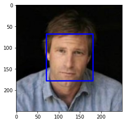

```python
import cv2
import matplotlib.pyplot as plt
%matplotlib inline

# extract pre-trained face detector
face_cascade = cv2.CascadeClassifier('haarcascades/haarcascade_frontalface_alt.xml')

# load color (BGR) image
img = cv2.imread(human_files[0])

# convert BGR image to grayscale
gray = cv2.cvtColor(img, cv2.COLOR_BGR2GRAY)

# find faces in image
faces = face_cascade.detectMultiScale(gray)

# print number of faces detected in the image
print('Number of faces detected:', len(faces))

# get bounding box for each detected face
for (x,y,w,h) in faces:
    # add bounding box to color image
    cv2.rectangle(img,(x,y),(x+w,y+h),(255,0,0),2)

# convert BGR image to RGB for plotting
cv_rgb = cv2.cvtColor(img, cv2.COLOR_BGR2RGB)

# display the image, along with bounding box
plt.imshow(cv_rgb)
plt.show()
```

Before using any of the face detectors, it is standard procedure to convert the images to grayscale. The `detectMultiScale` function executes the classifier stored in `face_cascade` and takes the grayscale image as a parameter.

In the above code, `faces` is a numpy array of detected faces, where each row corresponds to a detected face. Each detected face is a 1D array with four entries that specifies the bounding box of the detected face. The first two entries in the array (extracted in the above code as `x` and `y`) specify the horizontal and vertical positions of the top left corner of the bounding box. The last two entries in the array (extracted here as `w` and `h`) specify the width and height of the box.

### Human Face Detector

We can use this procedure to write a function that returns `True` if a human face is detected in an image and `False` otherwise. This function, aptly named `face_detector`, takes a string-valued file path to an image as input and appears in the code block below.

```python
# returns "True" if face is detected in image stored at img_path
def face_detector(img_path):
    img = cv2.imread(img_path)
    gray = cv2.cvtColor(img, cv2.COLOR_BGR2GRAY)
    faces = face_cascade.detectMultiScale(gray)
    return len(faces) > 0
```

```python
from tqdm import tqdm

human_files_short = human_files[:100]
dog_files_short = dog_files[:100]
#-#-# Do NOT modify the code above this line. #-#-#

## Test the performance of the face_detector algorithm
## on the images in human_files_short and dog_files_short.
counth = 0
countd = 0
for himg,dimg in zip(human_files_short,dog_files_short):
    img_human = cv2.imread(himg)
    img_dog = cv2.imread(dimg)

    # convert BGR images to grayscale images
    gray_human = cv2.cvtColor(img_human, cv2.COLOR_BGR2GRAY)
    gray_dog = cv2.cvtColor(img_dog, cv2.COLOR_BGR2GRAY)

    # find faces in images
    faces_h = face_cascade.detectMultiScale(gray_human)
    faces_d = face_cascade.detectMultiScale(gray_dog)

    if len(faces_h)>0:
        counth+=1
    if len(faces_d)>0:
        countd+=1

# Percentage Calculations

# Calculate the percentage of each types of images classified here
print(f"Human faces identified from human Images: {counth}%")
print(f"Human faces identified from Dog Images: {countd}%")
```

```
Human faces identified from human Images: 96%
Human faces identified from Dog Images: 18%
```

What we infer from out results:

- I was able to get 96% of human faces detected
- The human face detector detected 18% of the dog faces as Human faces.

## Step 2: Detect Dogs

In this section, we use a [pre-trained model](http://pytorch.org/docs/master/torchvision/models.html) to detect dogs in images.

### Obtain Pre-trained VGG-16 Model

The code cell below downloads the VGG-16 model, along with weights that have been trained on [ImageNet](http://www.image-net.org/), a very large, very popular dataset used for image classification and other vision tasks. ImageNet contains over 10 million URLs, each linking to an image containing an object from one of [1000 categories](https://gist.github.com/yrevar/942d3a0ac09ec9e5eb3a).

```python
import torch
import torchvision.models as models

# define VGG16 model
VGG16 = models.vgg16(pretrained=True)

# check if CUDA is available
use_cuda = torch.cuda.is_available()

# move model to GPU if CUDA is available
if use_cuda:
    VGG16 = VGG16.cuda()
```

Given an image, this pre-trained VGG-16 model returns a prediction (derived from the 1000 possible categories in ImageNet) for the object that is contained in the image.

### Making Predictions with a Pre-trained Model

In the next code cell, we will write a function that accepts a path to an image (such as `'dogImages/train/001.Affenpinscher/Affenpinscher_00001.jpg'`) as input and returns the index corresponding to the ImageNet class that is predicted by the pre-trained VGG-16 model. The output should always be an integer between 0 and 999, inclusive.

```python
from PIL import Image
from torchvision import transforms

# Set PIL to be tolerant of image files that are truncated.
from PIL import ImageFile
ImageFile.LOAD_TRUNCATED_IMAGES = True

def VGG16_predict(img_path):
    '''
    Use pre-trained VGG-16 model to obtain index corresponding to
    predicted ImageNet class for image at specified path

    Args:
        img_path: path to an image

    Returns:
        Index corresponding to VGG-16 model's prediction
    '''

    ## Load and pre-process an image from the given img_path
    ## Return the *index* of the predicted class for that image
    transform = transforms.Compose([transforms.CenterCrop(224),transforms.ToTensor(),
                                    transforms.Normalize(mean=[0.485, 0.456, 0.406],std=[0.229, 0.224, 0.225])])
    data = Image.open(img_path)
    data = transform(data)
    img = data.unsqueeze(0)
    img = img.cuda()
    VGG16.eval()
    output = VGG16(img)
    _, pred = torch.max(output, 1)
    return pred # predicted class index
```

### Dog Detector

While looking at the [dictionary](https://gist.github.com/yrevar/942d3a0ac09ec9e5eb3a), we can notice that the categories corresponding to dogs appear in an uninterrupted sequence and correspond to dictionary keys 151-268, inclusive, to include all categories from `'Chihuahua'` to `'Mexican hairless'`. Thus, in order to check to see if an image is predicted to contain a dog by the pre-trained VGG-16 model, we need only check if the pre-trained model predicts an index between 151 and 268 (inclusive).

Using these ideas we completed the `dog_detector` function below, which returns `True` if a dog is detected in an image (and `False` if not).

```python
### returns "True" if a dog is detected in the image stored at img_path
def dog_detector(img_path):
    ret_val = False
    prediction = VGG16_predict(img_path)
    if prediction in list(range(151,269)):
        ret_val = True
    return ret_val # true/false
```

### Assessment of the Dog Detector

```python
### Test the performance of the dog_detector function
### on the images in human_files_short and dog_files_short.
from tqdm import tqdm

human_files_short = human_files[:100]
dog_files_short = dog_files[:100]

counth = 0
countd = 0
for himg,dimg in zip(human_files_short,dog_files_short):

    # find dogs in images
    faces_h = dog_detector(himg)
    faces_d = dog_detector(dimg)

    if faces_h == True:
        counth+=1
    if faces_d == True:
        countd+=1

# Percentage Calculations

# Percentage of each types of images classified here
print(f"Dog faces identified from human Images: {counth}%")
print(f"Dog faces identified from Dog Images: {countd}%")
```

```
Dog faces identified from human Images: 0%
Dog faces identified from Dog Images: 91%
```

## Step 3: Create a CNN to Classify Dog Breeds (from Scratch)

Now that we have functions for detecting humans and dogs in images, we need a way to predict breed from images. In this step, you will create a CNN that classifies dog breeds. You must create your CNN *from scratch* (so, you can't use transfer learning *yet*!), and you must attain a test accuracy of at least 10%. In Step 4 of this notebook, you will have the opportunity to use transfer learning to create a CNN that attains greatly improved accuracy.

We mention that the task of assigning breed to dogs from images is considered exceptionally challenging. To see why, consider that *even a human* would have trouble distinguishing between a Brittany and a Welsh Springer Spaniel.

It is not difficult to find other dog breed pairs with minimal inter-class variation (for instance, Curly-Coated Retrievers and American Water Spaniels).

Likewise, recalling that labradors come in yellow, chocolate, and black. Our vision-based algorithm will have to conquer this high intra-class variation to determine how to classify all of these different shades as the same breed.

We also mention that random chance presents an exceptionally low bar: setting aside the fact that the classes are slightly imabalanced, a random guess will provide a correct answer roughly 1 in 133 times, which corresponds to an accuracy of less than 1%.  
Experiment with many different architectures, and trust your intuition.

### Data Loaders for the Dog Dataset

```python
import torch
import os
from torchvision import datasets

### Data loaders for training, validation, and test sets
## Including transforms and batch_sizes
from torchvision.transforms import transforms

batch_size = 32
num_workers = 0

data_dir = 'dogImages/'
train_dir = os.path.join(data_dir,'train/')
valid_dir = os.path.join(data_dir,'valid/')
test_dir = os.path.join(data_dir,'test/')


transform_train = transforms.Compose([transforms.Resize(256),
                                      transforms.CenterCrop(224),
                                      transforms.RandomApply(torch.nn.ModuleList([transforms.RandomAutocontrast(),
                                                                                transforms.ColorJitter(brightness=0.4,
                                                                                                       contrast=0.4,
                                                                                                       saturation=0.4,
                                                                                                       hue=0.2)]),
                                                           p=0.3),
                                      transforms.RandomVerticalFlip(p=0.5),
                                      transforms.RandomHorizontalFlip(p=0.5),
                                      transforms.RandomRotation(45),
                                      transforms.ToTensor(),
                                      transforms.Normalize(mean=[0.485, 0.456, 0.406],std=[0.229, 0.224, 0.225])])

transform_rest = transforms.Compose([transforms.Resize(256),
                                     transforms.CenterCrop(224),
                                     transforms.ToTensor(),
                                     transforms.Normalize(mean=[0.485, 0.456, 0.406],std=[0.229, 0.224, 0.225])])

train_data = datasets.ImageFolder(train_dir, transform=transform_train)
test_data = datasets.ImageFolder(test_dir, transform=transform_rest)
valid_data = datasets.ImageFolder(valid_dir, transform=transform_rest)

train_loader = torch.utils.data.DataLoader(train_data, batch_size=batch_size, num_workers=num_workers,shuffle=True)
valid_loader = torch.utils.data.DataLoader(train_data, batch_size=batch_size, num_workers=num_workers,shuffle=True)
test_loader = torch.utils.data.DataLoader(test_data, batch_size=batch_size, num_workers=num_workers,shuffle=True)

loaders_scratch = {'train':train_loader,'valid':valid_loader,'test':test_loader}
all_classes = train_data.classes
```

- My code resizes the image with the help of Resize function provided by torchvision.transforms. And then crops a portion of the image to the given size(h=224,w=224), so all the images are of identical sizes.
- Yes I did decide to augment the data by the help of Randomly adjusting contrast and adding color jitter in the image as well as used vertical flip and also horizontal flip as that kind of augmentation makes sense in this scenario. The model should be able to identify the dog breed even if a upside down picture is provided by the user, or a unusual lighting conditioned image of a dog.
- Finally i converted the image to a tensor and normalized the image tensor.

### Model Architecture

CNN to classify dog breed.

```python
import torch.nn as nn
import torch.nn.functional as F

# The CNN architecture
class Net(nn.Module):
    ### Our architecture
    def __init__(self):
        super(Net, self).__init__()
        ## Define layers of a CNN
        # 224*224
        self.conv1 = nn.Conv2d(3,16,3,padding=1)
        # 112*112
        self.conv2 = nn.Conv2d(16,32,3,padding=1)
        # 56*56
        # Make this 32,64
        self.conv3 = nn.Conv2d(32,32,3,padding=1)
        # 28*28
        # Also make this 64,64
        self.conv4 = nn.Conv2d(32,64,3,padding=1)
        # 14*14
        self.pool = nn.MaxPool2d(2, 2)
        self.fc1 = nn.Linear(64*14*14,4096)
        self.fc2 = nn.Linear(4096, 4096)
        self.fc3 = nn.Linear(4096,len(all_classes))
        self.dropout = nn.Dropout(0.5)

    def forward(self, x):
        ## Define forward behavior
        x = self.pool(F.relu(self.conv1(x)))
        x = self.pool(F.relu(self.conv2(x)))
        x = self.pool(F.relu(self.conv3(x)))
        x = self.pool(F.relu(self.conv4(x)))

        x = x.view(-1,64*14*14)
        x = self.dropout(x)
        x = F.relu(self.fc1(x))
        x = self.dropout(x)
        x = F.relu(self.fc2(x))
        x = self.dropout(x)
        x = F.relu(self.fc3(x))
        return x

# instantiate the CNN
model_scratch = Net()

# move tensors to GPU if CUDA is available
if use_cuda:
    model_scratch.cuda()
```

**What we infer from the above CNN we created:**

### Loss Function and Optimizer

Use the next code cell to specify a [loss function](http://pytorch.org/docs/stable/nn.html#loss-functions) and [optimizer](http://pytorch.org/docs/stable/optim.html). Save the chosen loss function as `criterion_scratch`, and the optimizer as `optimizer_scratch` below.

```python
import torch.optim as optim

### loss function
criterion_scratch = nn.CrossEntropyLoss()

### optimizer
optimizer_scratch = optim.SGD(model_scratch.parameters(),lr=0.01,momentum=0.9)
```

### Train and Validate the Model

Training and validating our model in the code cell below. [Saving the final model parameters](http://pytorch.org/docs/master/notes/serialization.html) at filepath `'model_scratch.pt'`.

```python
# the following import is required for training to be robust to truncated images
from PIL import ImageFile
ImageFile.LOAD_TRUNCATED_IMAGES = True

def train(n_epochs, loaders, model, optimizer, criterion, use_cuda, save_path):
    """returns trained model"""
    # initialize tracker for minimum validation loss
    valid_loss_min = np.Inf

    for epoch in range(1, n_epochs+1):
        # initialize variables to monitor training and validation loss
        train_loss = 0.0
        valid_loss = 0.0

        ###################
        # train the model #
        ###################
        model.train()
        for batch_idx, (data, target) in enumerate(loaders['train']):
            # move to GPU
            if use_cuda:
                data, target = data.cuda(), target.cuda()
            ## find the loss and update the model parameters accordingly
            ## record the average training loss, using something like
            ## train_loss = train_loss + ((1 / (batch_idx + 1)) * (loss.data - train_loss))
            optimizer_scratch.zero_grad()
            output = model_scratch(data)

            loss = criterion_scratch(output, target)
            loss.backward()

            optimizer_scratch.step()

            train_loss += loss.item()*data.size(0)

        ######################
        # validate the model #
        ######################
        model.eval()
        for batch_idx, (data, target) in enumerate(loaders['valid']):
            # move to GPU
            if use_cuda:
                data, target = data.cuda(), target.cuda()
            ## update the average validation loss
            output = model_scratch(data)

            loss = criterion_scratch(output, target)
            loss.backward()

            valid_loss+= loss.item()*data.size(0)


        train_loss = train_loss/len(loaders['train'].dataset)
        valid_loss = valid_loss/len(loaders['valid'].dataset)

        # print training/validation statistics
        print('Epoch: {} \tTraining Loss: {:.6f} \tValidation Loss: {:.6f}'.format(
            epoch,
            train_loss,
            valid_loss
            ))
        if valid_loss <= valid_loss_min:
            print('Validation loss decreased ({:.6f} --> {:.6f}).  Saving model ...'.format(valid_loss_min,valid_loss))
            torch.save(model_scratch.state_dict(), save_path)
            valid_loss_min = valid_loss

        ## save the model if validation loss has decreased

    # return trained model
    return model


# train the model
model_scratch = train(50, loaders_scratch, model_scratch, optimizer_scratch,
                      criterion_scratch, use_cuda, 'model_scratch.pt')

# load the model that got the best validation accuracy
model_scratch.load_state_dict(torch.load('model_scratch.pt'))
```

```
Epoch: 1 	Training Loss: 4.887627 	Validation Loss: 4.877189
Validation loss decreased (inf --> 4.877189).  Saving model ...
Epoch: 2 	Training Loss: 4.875196 	Validation Loss: 4.851667
Validation loss decreased (4.877189 --> 4.851667).  Saving model ...
Epoch: 3 	Training Loss: 4.845540 	Validation Loss: 4.831325
Validation loss decreased (4.851667 --> 4.831325).  Saving model ...
Epoch: 4 	Training Loss: 4.794459 	Validation Loss: 4.776990
Validation loss decreased (4.831325 --> 4.776990).  Saving model ...
Epoch: 5 	Training Loss: 4.765041 	Validation Loss: 4.743301
Validation loss decreased (4.776990 --> 4.743301).  Saving model ...
Epoch: 6 	Training Loss: 4.705273 	Validation Loss: 4.628297
Validation loss decreased (4.743301 --> 4.628297).  Saving model ...
Epoch: 7 	Training Loss: 4.642514 	Validation Loss: 4.578653
Validation loss decreased (4.628297 --> 4.578653).  Saving model ...
Epoch: 8 	Training Loss: 4.604123 	Validation Loss: 4.519504
Validation loss decreased (4.578653 --> 4.519504).  Saving model ...
Epoch: 9 	Training Loss: 4.557955 	Validation Loss: 4.611138
Epoch: 10 	Training Loss: 4.525695 	Validation Loss: 4.470953
Validation loss decreased (4.519504 --> 4.470953).  Saving model ...
Epoch: 11 	Training Loss: 4.489557 	Validation Loss: 4.427724
Validation loss decreased (4.470953 --> 4.427724).  Saving model ...
Epoch: 12 	Training Loss: 4.459271 	Validation Loss: 4.393278
Validation loss decreased (4.427724 --> 4.393278).  Saving model ...
Epoch: 13 	Training Loss: 4.429453 	Validation Loss: 4.363666
Validation loss decreased (4.393278 --> 4.363666).  Saving model ...
Epoch: 14 	Training Loss: 4.418816 	Validation Loss: 4.349061
Validation loss decreased (4.363666 --> 4.349061).  Saving model ...
Epoch: 15 	Training Loss: 4.413034 	Validation Loss: 4.293513
Validation loss decreased (4.349061 --> 4.293513).  Saving model ...
Epoch: 16 	Training Loss: 4.367622 	Validation Loss: 4.282313
Validation loss decreased (4.293513 --> 4.282313).  Saving model ...
Epoch: 17 	Training Loss: 4.319649 	Validation Loss: 4.234472
Validation loss decreased (4.282313 --> 4.234472).  Saving model ...
Epoch: 18 	Training Loss: 4.298603 	Validation Loss: 4.227079
Validation loss decreased (4.234472 --> 4.227079).  Saving model ...
Epoch: 19 	Training Loss: 4.260980 	Validation Loss: 4.165484
Validation loss decreased (4.227079 --> 4.165484).  Saving model ...
Epoch: 20 	Training Loss: 4.243476 	Validation Loss: 4.123512
Validation loss decreased (4.165484 --> 4.123512).  Saving model ...
Epoch: 21 	Training Loss: 4.218515 	Validation Loss: 4.050116
```

[output cut: 33 more lines]

```
Epoch: 42 	Training Loss: 3.498136 	Validation Loss: 3.301603
Epoch: 43 	Training Loss: 3.471698 	Validation Loss: 3.232834
Validation loss decreased (3.296938 --> 3.232834).  Saving model ...
Epoch: 44 	Training Loss: 3.477691 	Validation Loss: 3.225304
Validation loss decreased (3.232834 --> 3.225304).  Saving model ...
Epoch: 45 	Training Loss: 3.436279 	Validation Loss: 3.118803
Validation loss decreased (3.225304 --> 3.118803).  Saving model ...
Epoch: 46 	Training Loss: 3.423742 	Validation Loss: 3.111009
Validation loss decreased (3.118803 --> 3.111009).  Saving model ...
Epoch: 47 	Training Loss: 3.398215 	Validation Loss: 3.064856
Validation loss decreased (3.111009 --> 3.064856).  Saving model ...
Epoch: 48 	Training Loss: 3.367762 	Validation Loss: 3.159487
Epoch: 49 	Training Loss: 3.319277 	Validation Loss: 2.999948
Validation loss decreased (3.064856 --> 2.999948).  Saving model ...
Epoch: 50 	Training Loss: 3.308694 	Validation Loss: 3.050292
```

```
<All keys matched successfully>
```

### Test the Model

Ensuring that our test accuracy is greater than 10%.

```python
model_scratch.load_state_dict(torch.load('model_scratch.pt'))
```

```
<All keys matched successfully>
```

```python
def test(loaders, model, criterion, use_cuda):

    # monitor test loss and accuracy
    test_loss = 0.
    correct = 0.
    total = 0.

    model.eval()
    for batch_idx, (data, target) in enumerate(loaders['test']):
        # move to GPU
        if use_cuda:
            data, target = data.cuda(), target.cuda()
        # forward pass: compute predicted outputs by passing inputs to the model
        output = model(data)
        # calculate the loss
        loss = criterion(output, target)
        # update average test loss
        test_loss = test_loss + ((1 / (batch_idx + 1)) * (loss.data - test_loss))
        # convert output probabilities to predicted class
        pred = output.data.max(1, keepdim=True)[1]
        # compare predictions to true label
        correct += np.sum(np.squeeze(pred.eq(target.data.view_as(pred))).cpu().numpy())
        total += data.size(0)

    print('Test Loss: {:.6f}\n'.format(test_loss))

    print('\nTest Accuracy: %2d%% (%2d/%2d)' % (
        100. * correct / total, correct, total))

# call test function
test(loaders_scratch, model_scratch, criterion_scratch, use_cuda)
```

```
Test Loss: 3.452329


Test Accuracy: 17% (144/836)
```

## Step 4: CNN to Classify Dog Breeds (using Transfer Learning)

We will now use transfer learning to create a CNN that can identify dog breed from images. Our CNN must attain at least 60% accuracy on the test set.

### Data Loaders for the Dog Dataset

```python
## data loaders
import torch
import os
from torchvision import datasets
from torchvision.transforms import transforms

batch_size = 64
num_workers = 0

data_dir = 'dogImages/'
train_dir = os.path.join(data_dir,'train/')
valid_dir = os.path.join(data_dir,'valid/')
test_dir = os.path.join(data_dir,'test/')


transform_train = transforms.Compose([transforms.Resize(256),
                                      transforms.CenterCrop(224),
                                      transforms.RandomApply(torch.nn.ModuleList([transforms.RandomAutocontrast(),
                                                                                transforms.ColorJitter(brightness=0.4,
                                                                                                       contrast=0.4,
                                                                                                       saturation=0.4,
                                                                                                       hue=0.2)]),
                                                           p=0.3),
                                      transforms.RandomVerticalFlip(p=0.5),
                                      transforms.RandomHorizontalFlip(p=0.5),
                                      transforms.RandomRotation(45),
                                      transforms.ToTensor(),
                                      transforms.Normalize(mean=[0.485, 0.456, 0.406],std=[0.229, 0.224, 0.225])])

transform_rest = transforms.Compose([transforms.Resize(256),
                                     transforms.CenterCrop(224),
                                     transforms.ToTensor(),
                                     transforms.Normalize(mean=[0.485, 0.456, 0.406],std=[0.229, 0.224, 0.225])])

train_data = datasets.ImageFolder(train_dir, transform=transform_train)
test_data = datasets.ImageFolder(test_dir, transform=transform_rest)
valid_data = datasets.ImageFolder(valid_dir, transform=transform_rest)

train_loader = torch.utils.data.DataLoader(train_data, batch_size=batch_size, num_workers=num_workers,shuffle=True)
valid_loader = torch.utils.data.DataLoader(train_data, batch_size=batch_size, num_workers=num_workers,shuffle=True)
test_loader = torch.utils.data.DataLoader(test_data, batch_size=batch_size, num_workers=num_workers,shuffle=True)

loaders_transfer = {'train':train_loader,'valid':valid_loader,'test':test_loader}
all_classes = train_data.classes
```

### Model Architecture

We save your initialized model as the variable `model_transfer`.

```python
import torchvision.models as models
import torch.nn as nn
from collections import OrderedDict

## model architecture
model_transfer = models.resnet50(pretrained=True)


model_transfer.fc = nn.Sequential(OrderedDict([('fc1', nn.Linear(model_transfer.fc.in_features, model_transfer.fc.out_features)),
                                        ('relu', nn.ReLU()),
                                        ('fc2', nn.Linear(model_transfer.fc.out_features, len(all_classes))),
                                        ('output', nn.LogSoftmax(dim=1))
                                       ]))


import re


regex = r"^fc"
for params,val in model_transfer.named_parameters():
    if re.search(regex, params):
        pass
    else:
        val.requires_grad = False

if use_cuda:
    model_transfer = model_transfer.cuda()
```

### Loss Function and Optimizer

```python
import torch.optim as optim
criterion_transfer = nn.CrossEntropyLoss()
optimizer_transfer = optim.Adam(model_transfer.parameters(), lr=0.001)
```

### Train and Validate the Model

Training and validating our model in the code cell below. [Saving the final model parameters](http://pytorch.org/docs/master/notes/serialization.html) at filepath `'model_transfer.pt'`.

```python
# train the model
import numpy as np
from PIL import ImageFile
ImageFile.LOAD_TRUNCATED_IMAGES = True

def train(n_epochs, loaders, model, optimizer, criterion, use_cuda, save_path):
    """returns trained model"""
    # initialize tracker for minimum validation loss
    valid_loss_min = np.Inf

    for epoch in range(1, n_epochs+1):
        # initialize variables to monitor training and validation loss
        train_loss = 0.0
        valid_loss = 0.0

        ###################
        # train the model #
        ###################
        model.train()
        for batch_idx, (data, target) in enumerate(loaders['train']):
            # move to GPU
            if use_cuda:
                data, target = data.cuda(), target.cuda()
            ## find the loss and update the model parameters accordingly
            ## record the average training loss, using something like
            ## train_loss = train_loss + ((1 / (batch_idx + 1)) * (loss.data - train_loss))
            optimizer.zero_grad()
            output = model(data)

            loss = criterion(output, target)
            loss.backward()

            optimizer.step()

            train_loss += loss.item()*data.size(0)

        ######################
        # validate the model #
        ######################
        model.eval()
        for batch_idx, (data, target) in enumerate(loaders['valid']):
            # move to GPU
            if use_cuda:
                data, target = data.cuda(), target.cuda()
            ## update the average validation loss
            output = model(data)

            loss = criterion(output, target)
            loss.backward()

            valid_loss+= loss.item()*data.size(0)


        train_loss = train_loss/len(loaders['train'].dataset)
        valid_loss = valid_loss/len(loaders['valid'].dataset)

        # print training/validation statistics
        print('Epoch: {} \tTraining Loss: {:.6f} \tValidation Loss: {:.6f}'.format(
            epoch,
            train_loss,
            valid_loss
            ))

        ## save the model if validation loss has decreased
        if valid_loss <= valid_loss_min:
            print('Validation loss decreased ({:.6f} --> {:.6f}).  Saving model ...'.format(valid_loss_min,valid_loss))
            torch.save(model.state_dict(), 'model_transfer.pt')
            valid_loss_min = valid_loss



    # return trained model
    return model
model_transfer = train(20, loaders_transfer, model_transfer, optimizer_transfer, criterion_transfer, use_cuda, 'model_transfer.pt')

# load the model that got the best validation accuracy (uncomment the line below)
model_transfer.load_state_dict(torch.load('model_transfer.pt'))
```

```
Epoch: 1 	Training Loss: 3.680453 	Validation Loss: 2.247186
Validation loss decreased (inf --> 2.247186).  Saving model ...
Epoch: 2 	Training Loss: 2.028544 	Validation Loss: 1.693348
Validation loss decreased (2.247186 --> 1.693348).  Saving model ...
Epoch: 3 	Training Loss: 1.682291 	Validation Loss: 1.524876
Validation loss decreased (1.693348 --> 1.524876).  Saving model ...
Epoch: 4 	Training Loss: 1.584009 	Validation Loss: 1.415084
Validation loss decreased (1.524876 --> 1.415084).  Saving model ...
Epoch: 5 	Training Loss: 1.438621 	Validation Loss: 1.298561
Validation loss decreased (1.415084 --> 1.298561).  Saving model ...
Epoch: 6 	Training Loss: 1.378620 	Validation Loss: 1.237037
Validation loss decreased (1.298561 --> 1.237037).  Saving model ...
Epoch: 7 	Training Loss: 1.355929 	Validation Loss: 1.214842
Validation loss decreased (1.237037 --> 1.214842).  Saving model ...
Epoch: 8 	Training Loss: 1.290101 	Validation Loss: 1.205812
Validation loss decreased (1.214842 --> 1.205812).  Saving model ...
Epoch: 9 	Training Loss: 1.281237 	Validation Loss: 1.151986
Validation loss decreased (1.205812 --> 1.151986).  Saving model ...
Epoch: 10 	Training Loss: 1.231021 	Validation Loss: 1.077264
Validation loss decreased (1.151986 --> 1.077264).  Saving model ...
Epoch: 11 	Training Loss: 1.217979 	Validation Loss: 1.046009
Validation loss decreased (1.077264 --> 1.046009).  Saving model ...
Epoch: 12 	Training Loss: 1.178884 	Validation Loss: 1.091678
Epoch: 13 	Training Loss: 1.182952 	Validation Loss: 1.059253
Epoch: 14 	Training Loss: 1.136566 	Validation Loss: 1.026230
Validation loss decreased (1.046009 --> 1.026230).  Saving model ...
Epoch: 15 	Training Loss: 1.128910 	Validation Loss: 0.981828
Validation loss decreased (1.026230 --> 0.981828).  Saving model ...
Epoch: 16 	Training Loss: 1.097373 	Validation Loss: 0.988865
Epoch: 17 	Training Loss: 1.098545 	Validation Loss: 0.958614
Validation loss decreased (0.981828 --> 0.958614).  Saving model ...
Epoch: 18 	Training Loss: 1.086883 	Validation Loss: 0.952696
Validation loss decreased (0.958614 --> 0.952696).  Saving model ...
Epoch: 19 	Training Loss: 1.054399 	Validation Loss: 0.888100
Validation loss decreased (0.952696 --> 0.888100).  Saving model ...
Epoch: 20 	Training Loss: 1.033390 	Validation Loss: 0.896099
```

```
<All keys matched successfully>
```

### Test the Model

We ensure that our test accuracy is greater than 60%.

```python
def test(loaders, model, criterion, use_cuda):

    # monitor test loss and accuracy
    test_loss = 0.
    correct = 0.
    total = 0.

    model.eval()
    for batch_idx, (data, target) in enumerate(loaders['test']):
        # move to GPU
        if use_cuda:
            data, target = data.cuda(), target.cuda()
        # forward pass: compute predicted outputs by passing inputs to the model
        output = model(data)
        # calculate the loss
        loss = criterion(output, target)
        # update average test loss
        test_loss = test_loss + ((1 / (batch_idx + 1)) * (loss.data - test_loss))
        # convert output probabilities to predicted class
        pred = output.data.max(1, keepdim=True)[1]
        # compare predictions to true label
        correct += np.sum(np.squeeze(pred.eq(target.data.view_as(pred))).cpu().numpy())
        total += data.size(0)

    print('Test Loss: {:.6f}\n'.format(test_loss))

    print('\nTest Accuracy: %2d%% (%2d/%2d)' % (
        100. * correct / total, correct, total))

test(loaders_transfer, model_transfer, criterion_transfer, use_cuda)
```

```
Test Loss: 0.620071


Test Accuracy: 82% (687/836)
```

### Predict Dog Breed with the Model

We write a function that takes an image path as input and returns the dog breed (`Affenpinscher`, `Afghan hound`, etc) that is predicted by our model.

```python
### Function that takes a path to an image as input
### and returns the dog breed that is predicted by the model.

# list of class names by index, i.e. a name can be accessed like class_names[0]
class_names = [item[4:].replace("_", " ") for item in all_classes]

def predict_breed_transfer(img_path):
    from PIL import Image
    data = Image.open(img_path)
    data = transform_rest(data)
    img = data.unsqueeze(0)
    img = img.cuda()
    model_transfer.eval()
    output = model_transfer(img)
    # load the image and return the predicted breed
    _, pred = torch.max(output, 1)
    opt = class_names[pred]
    return opt

predict_breed_transfer("dogImages/Beagles-standing-in-a-frosty-field-on-a-cold-morning.jpg")
```

```
'Beagle'
```

## Step 5: Write our Algorithm

We write an algorithm that accepts a file path to an image and first determines whether the image contains a human, dog, or neither. Then,

- if a **dog** is detected in the image, return the predicted breed.
- if a **human** is detected in the image, return the resembling dog breed.
- if **neither** is detected in the image, provide output that indicates an error.

### Our Algorithm

```python
### Oour algorithm.

def run_app(img_path):
    ## handle cases for a human face, dog, and neither
    if dog_detector(img_path)==True:
        return predict_breed_transfer(img_path)
    elif face_detector(img_path)==True:
        return predict_breed_transfer(img_path)
    else:
        print("Error in Detection!")
```

## Step 6: Test our Algorithm

### Test our Algorithm on Sample Images!

- So I used 3 human images where
  - **One had a sideways face**
  - **Other normal face**
  - **The last one as a anime human face**
- For 3 dog mages as well I used the same pattern
  - **One had a sideways dog picture**
  - **Other normal dog picture**
  - **The last one as a anime dog picture**

  #### Final Conclusion **`Surprisingy the results were exactly as I expected except for one. Anime faces were not detected which totally makes sense. But the human face with a side view was also not detedted. So As per my conclusion I am satisfied but I also think that we didn't train our human detector with skewed human faces so I guess the output was as expected to be!`**

```python
## We execute our algorithm from Step 6 on
## at least 6 images on your computer.

human_files = np.array(glob("dogImages/human*"))
dog_files = np.array(glob("dogImages/dog*"))

for file in np.hstack((human_files[:3], dog_files[:3])):
    print(run_app(file))
```

```
Error in Detection!
None
Afghan hound
Error in Detection!
None
Error in Detection!
None
Beagle
Alaskan malamute
```